# Models/Methods/Code Supplement

Catherine DeJager, Sarah Gilbert, and Kaitlyn Westra

November 22, 2019

### Read in Data

```r
load(file = "data/tedsd_2017.RData")
```

```r
tedsd_MI2017 <- filter(tedsd_puf_2017, STFIPS == 26)
tedsd_MI2017 <- tedsd_MI2017 %>%
  mutate(rowgroups = gl(n=(nrow(tedsd_MI2017)/250),
                        k = 250))
```

```r
tedsd_MI2017 <- tedsd_MI2017 %>%
  mutate(OPIFLG = HERFLG==1 | METHFLG==1 | OPSYNFLG==1,
         HER1 = SUB1==5, HER2 = SUB2==5, HER3 = SUB3==5, METH1 = SUB1==6, METH2 = SUB2==6,
         METH3 = SUB3==6, OPSYN1 = SUB1==7, OPSYN2 = SUB1==7, OPSYN3 = SUB3==7)
tedsd_MI2017 <- tedsd_MI2017 %>% mutate(OPI1 = HER1|METH1|OPSYN1, OPI2 =
                                          HER2|METH2|OPSYN2, OPI3 = HER3|METH3|OPSYN3)
tedsd_MI2017 <- tedsd_MI2017 %>% mutate(MULTIOPI = (OPI1 & OPI2) | (OPI1 & OPI3) |
                                          (OPI2 & OPI3))
```

```r
remove_nas <- function(df) {
  M <- as.matrix(df)
  M[M == -9] <- NA
  result <- as.data.frame(M)
  result <- result %>% na.omit()
}
```

```r
tedsd_MI2017_notna <- tedsd_MI2017 %>% select(HERFLG, METHFLG, OPSYNFLG, OPIFLG, HER1,
      HER2, HER3, METH1, METH2, METH3, OPSYN1, OPSYN2, OPSYN3, OPI1, OPI2, OPI3, MULTIOPI,
      AGE, GENDER, RACE, MARSTAT, EDUC, EMPLOY, LIVARAG, ARRESTS, NOPRIOR, PSYPROB,
      FREQ_ATND_SELF_HELP, LOS, PSOURCE, rowgroups)
tedsd_MI2017_notna <- tedsd_MI2017_notna %>% remove_nas()
```

```r
tedsd_MI2017_notna <- tedsd_MI2017_notna %>% mutate(
    AGE = factor(AGE, labels = c("12-14", "15-17", "18-20", "21-24", "25-29", "30-34",
                                 "35-39", "40-44", "45-49", "50-54", "55-64", "65+")),
    GENDER = factor(as.numeric(GENDER==2.0), labels = c("M", "F")),
    RACE = factor(RACE, labels = c("AK Native", "American Indian", "Black", "White",
                              "Asian", "Other", "Multiple", "HI/other pacific islander")),
    MARSTAT = factor(MARSTAT, labels = c("Never", "Married", "Separated",
                                         "Divorced/widowed")),
    EDUC = factor(EDUC, labels = c("<=8", "9-11", "12 or GED", "13-15", "16+")),
    EMPLOY = factor(EMPLOY, labels = c("Full-time", "Part-time", "Unemployed",
                                       "Not in labor force")),
    LIVARAG = factor(LIVARAG, labels = c("Homeless", "Dependent", "Independent")) %>% relevel(ref = "Independent"),
    ARRESTS = factor(ARRESTS, labels = c("0", "1", "2+")),
    NOPRIOR = factor(NOPRIOR, labels = c("0", "1+")),
    PSYPROB = factor(as.numeric(PSYPROB == 1)),
    FREQ_ATND_SELF_HELP = factor(FREQ_ATND_SELF_HELP, labels = c("0", "1-3", "4-7",
                                                                 "8-30")),
    LOS = factor(LOS, labels = c(seq(from = 1, to = 30), "31-45", "46-60", "61-90",
                                 "91-120", "121-180", "181-365", ">365")),
    PSOURCE = factor(PSOURCE, labels = c("Individual", "Alcohol/drug use care provider",
      "Other health care provider", "School", "Employer/EAP", "Other community", "Court"))
    )
tedsd_MI2017_notna <- tedsd_MI2017_notna %>% mutate_if(is.double, as.factor)
```

```r
tedsd_MI2017_opi <- tedsd_MI2017_notna %>% filter(OPIFLG == TRUE)
head(tedsd_MI2017_opi)
```

```
##   HERFLG METHFLG OPSYNFLG OPIFLG  HER1  HER2  HER3 METH1 METH2 METH3
## 1      1       0        0   TRUE  TRUE FALSE FALSE FALSE FALSE FALSE
## 2      1       0        0   TRUE  TRUE FALSE FALSE FALSE FALSE FALSE
## 3      1       0        1   TRUE  TRUE FALSE FALSE FALSE FALSE FALSE
## 4      1       0        1   TRUE FALSE FALSE  TRUE FALSE FALSE FALSE
## 5      0       0        1   TRUE FALSE FALSE FALSE FALSE FALSE FALSE
## 6      0       0        1   TRUE FALSE FALSE FALSE FALSE FALSE FALSE
##   OPSYN1 OPSYN2 OPSYN3 OPI1  OPI2  OPI3 MULTIOPI   AGE GENDER      RACE
## 1  FALSE  FALSE  FALSE TRUE FALSE FALSE    FALSE 40-44      F AK Native
## 2  FALSE  FALSE  FALSE TRUE FALSE FALSE    FALSE 25-29      F  Multiple
## 3  FALSE  FALSE   TRUE TRUE FALSE  TRUE     TRUE 25-29      M  Multiple
## 4   TRUE   TRUE  FALSE TRUE  TRUE  TRUE     TRUE 40-44      F AK Native
## 5   TRUE   TRUE  FALSE TRUE  TRUE FALSE     TRUE 25-29      F     Black
## 6   TRUE   TRUE  FALSE TRUE  TRUE FALSE     TRUE 25-29      F     Black
##            MARSTAT      EDUC             EMPLOY     LIVARAG ARRESTS
```

[output cut: 20 more lines]

```r
percents_graphs_tables <- function(form, ttl, my_df, horiz=FALSE) {
  if (horiz) {
    print(gf_percentsh(form, title=ttl, data=my_df))
  }
  else {
    print(gf_percents(form, title=ttl, data=my_df))
  }
  tally(form, format='percent', data=my_df) #%>% pander()
}
```

```r
predict_model <- function(model,predictor){
  orig_dat <- model@frame
  fixed_vals <- get_fixed(orig_dat[,(2:ncol(orig_dat))])
  new_dat <- get_new_data(orig_dat, predictor = predictor, fixed_vals)
  return(predict(model, newdata = new_dat,
                 type = 'response', allow.new.levels = TRUE))
}
```

### Models

#### Question 1: What variables predict whether a person entering treatment uses opioids or not?

We’ll use a Logistic Regression here:

(OPIFLG ~ GENDER + MARSTAT + GENDER*MARSTAT + GENDER*EMPLOY + LIVARAG + LIVARAG*EDUC + LIVARAG*EMPLOY + NOPRIOR + FREQ_ATND_SELF_HELP)

EDUC = education, LIVARAG = living arrangement, NOPRIOR = whether the person has been admitted before, FREQ_ATND_SELF_HELP = frequency of attending self-help in the past 30 days

```r
opiModel <- glmmTMB(OPIFLG ~ GENDER + MARSTAT + GENDER*MARSTAT + GENDER*EMPLOY + LIVARAG + LIVARAG*EDUC +
                  LIVARAG*EMPLOY + NOPRIOR + FREQ_ATND_SELF_HELP + (1|rowgroups), family=binomial(link="logit"), data=tedsd_MI2017_notna)
summary(opiModel)
```

```
##  Family: binomial  ( logit )
## Formula:
## OPIFLG ~ GENDER + MARSTAT + GENDER * MARSTAT + GENDER * EMPLOY +
##     LIVARAG + LIVARAG * EDUC + LIVARAG * EMPLOY + NOPRIOR + FREQ_ATND_SELF_HELP +
##     (1 | rowgroups)
## Data: tedsd_MI2017_notna
##
##      AIC      BIC   logLik deviance df.resid
##  73400.8  73752.3 -36661.4  73322.8    60583
##
## Random effects:
##
## Conditional model:
##  Groups    Name        Variance Std.Dev.
##  rowgroups (Intercept) 0.6801   0.8247
## Number of obs: 60622, groups:  rowgroups, 254
##
## Conditional model:
##                                           Estimate Std. Error z value
## (Intercept)                               -0.95043    0.10166   -9.35
## GENDERF                                    0.23148    0.06863    3.37
## MARSTATMarried                            -0.04696    0.03947   -1.19
## MARSTATSeparated                          -0.10090    0.05451   -1.85
## MARSTATDivorced/widowed                   -0.56473    0.03061  -18.45
## EMPLOYPart-time                            0.17933    0.06328    2.83
## EMPLOYUnemployed                           0.51967    0.04465   11.64
## EMPLOYNot in labor force                   0.39746    0.05603    7.09
## LIVARAGHomeless                            0.63780    0.21255    3.00
## LIVARAGDependent                           0.09913    0.16430    0.60
## EDUC9-11                                   0.06118    0.07996    0.77
## EDUC12 or GED                              0.06828    0.07732    0.88
## EDUC13-15                                 -0.07970    0.07905   -1.01
## EDUC16+                                   -0.66239    0.09318   -7.11
## NOPRIOR1+                                  0.73452    0.02173   33.80
## FREQ_ATND_SELF_HELP1-3                    -0.03261    0.03683   -0.89
## FREQ_ATND_SELF_HELP4-7                     0.08922    0.04522    1.97
## FREQ_ATND_SELF_HELP8-30                   -0.08482    0.03409   -2.49
## GENDERF:MARSTATMarried                     0.11650    0.06317    1.84
## GENDERF:MARSTATSeparated                   0.11885    0.08204    1.45
## GENDERF:MARSTATDivorced/widowed            0.25316    0.04698    5.39
```

[output cut: 43 more lines]

```
## LIVARAGDependent:EDUC9-11                 0.069849 .
## LIVARAGHomeless:EDUC12 or GED             0.021003 *
## LIVARAGDependent:EDUC12 or GED            0.812811
## LIVARAGHomeless:EDUC13-15                 0.611190
## LIVARAGDependent:EDUC13-15                0.232196
## LIVARAGHomeless:EDUC16+                   0.884245
## LIVARAGDependent:EDUC16+                  0.659209
## EMPLOYPart-time:LIVARAGHomeless           0.058984 .
## EMPLOYUnemployed:LIVARAGHomeless          0.000453 ***
## EMPLOYNot in labor force:LIVARAGHomeless  6.75e-06 ***
## EMPLOYPart-time:LIVARAGDependent          0.118869
## EMPLOYUnemployed:LIVARAGDependent         0.755859
## EMPLOYNot in labor force:LIVARAGDependent 0.040359 *
## ---
## Signif. codes:  0 '***' 0.001 '**' 0.01 '*' 0.05 '.' 0.1 ' ' 1
```

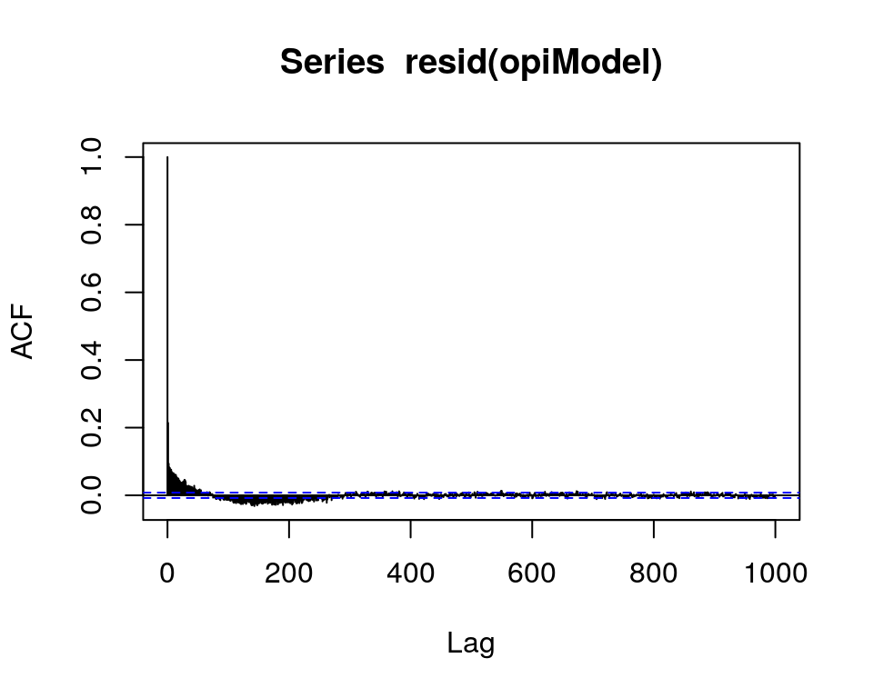

```r
acf(resid(opiModel),lag.max=1000)
```

This ACF was the best we could do. It’s not *super* great, but it’s a lot better than what we started with, indicating that our random effect variable (rowgroup) helped with the independence of residuals.

```r
Anova(opiModel)
```

```
## Analysis of Deviance Table (Type II Wald chisquare tests)
##
## Response: OPIFLG
##                         Chisq Df Pr(>Chisq)
## GENDER               367.1638  1  < 2.2e-16 ***
## MARSTAT              397.9147  3  < 2.2e-16 ***
## EMPLOY               392.1589  3  < 2.2e-16 ***
## LIVARAG               92.6561  2  < 2.2e-16 ***
## EDUC                 209.0038  4  < 2.2e-16 ***
## NOPRIOR             1142.3893  1  < 2.2e-16 ***
## FREQ_ATND_SELF_HELP   12.1746  3   0.006808 **
## GENDER:MARSTAT        30.1468  3  1.285e-06 ***
## GENDER:EMPLOY          9.1564  3   0.027282 *
## LIVARAG:EDUC          60.9794  8  2.994e-10 ***
## EMPLOY:LIVARAG        38.5236  6  8.873e-07 ***
## ---
## Signif. codes:  0 '***' 0.001 '**' 0.01 '*' 0.05 '.' 0.1 ' ' 1
```

##### Prediction Plots:

We’d like to be able to show prediction plots for: gender, marstat, noprior.

#### Question 2: What variables predict whether a person entering treatment uses more than one kind of opioid?

We’re using a Logistic Regression here:

(MULTIOPI ~ HERFLG + METHFLG + OPSYNFLG + AGE + GENDER + NOPRIOR)

NOPRIOR = whether the person has been admitted before

```r
multiOpiBest <- glmmTMB(MULTIOPI ~ HERFLG + METHFLG + OPSYNFLG + AGE + GENDER +
                      NOPRIOR + (1|rowgroups), data = tedsd_MI2017_opi,
                     family = binomial(link = "logit"))
```

```r
summary(multiOpiBest)
```

```
##  Family: binomial  ( logit )
## Formula:
## MULTIOPI ~ HERFLG + METHFLG + OPSYNFLG + AGE + GENDER + NOPRIOR +
##     (1 | rowgroups)
## Data: tedsd_MI2017_opi
##
##      AIC      BIC   logLik deviance df.resid
##  15079.3  15220.6  -7522.7  15045.3    30104
##
## Random effects:
##
## Conditional model:
##  Groups    Name        Variance Std.Dev.
##  rowgroups (Intercept) 0.1818   0.4264
## Number of obs: 30121, groups:  rowgroups, 254
##
## Conditional model:
##             Estimate Std. Error z value Pr(>|z|)
## (Intercept) -6.52666    0.39022  -16.73  < 2e-16 ***
## HERFLG1     -1.21251    0.04631  -26.19  < 2e-16 ***
## METHFLG1     4.72751    0.18731   25.24  < 2e-16 ***
## OPSYNFLG1    5.53198    0.14007   39.49  < 2e-16 ***
## AGE18-20     1.22133    0.38827    3.15 0.001658 **
## AGE21-24     1.79514    0.36946    4.86 1.18e-06 ***
## AGE25-29     1.93898    0.36470    5.32 1.06e-07 ***
## AGE30-34     1.89699    0.36460    5.20 1.96e-07 ***
## AGE35-39     1.99017    0.36581    5.44 5.31e-08 ***
## AGE40-44     1.79305    0.36876    4.86 1.16e-06 ***
## AGE45-49     1.38909    0.37064    3.75 0.000178 ***
## AGE50-54     1.44342    0.37238    3.88 0.000106 ***
## AGE55-64     1.54753    0.37207    4.16 3.19e-05 ***
## AGE65+       1.72803    0.48183    3.59 0.000335 ***
## GENDERF      0.29846    0.04150    7.19 6.36e-13 ***
## NOPRIOR1+   -0.16233    0.04818   -3.37 0.000755 ***
## ---
## Signif. codes:  0 '***' 0.001 '**' 0.01 '*' 0.05 '.' 0.1 ' ' 1
```

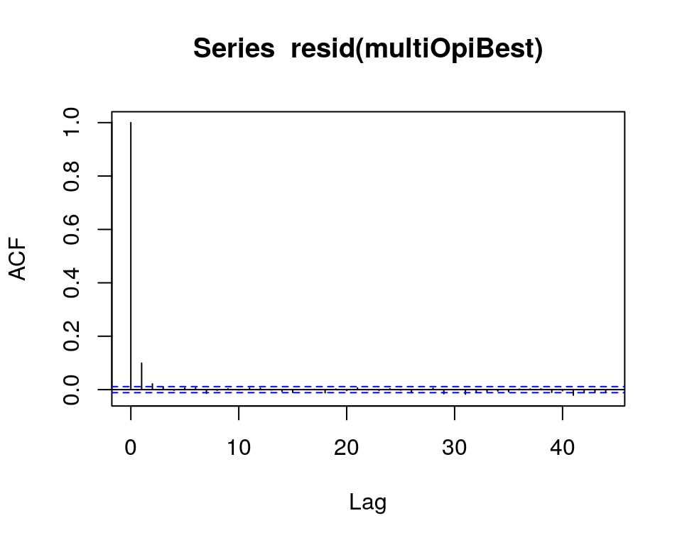

```r
acf(resid(multiOpiBest))
```

Again, this ACF was the best we could do. It’s a lot better than what we started with, indicating that our random effect variable (rowgroup) helped with the independence of residuals.

```r
Anova(multiOpiBest)
```

```
## Analysis of Deviance Table (Type II Wald chisquare tests)
##
## Response: MULTIOPI
##             Chisq Df Pr(>Chisq)
## HERFLG    685.663  1  < 2.2e-16 ***
## METHFLG   636.974  1  < 2.2e-16 ***
## OPSYNFLG 1559.729  1  < 2.2e-16 ***
## AGE       122.355 10  < 2.2e-16 ***
## GENDER     51.734  1  6.356e-13 ***
## NOPRIOR    11.349  1  0.0007549 ***
## ---
## Signif. codes:  0 '***' 0.001 '**' 0.01 '*' 0.05 '.' 0.1 ' ' 1
```

##### The important predictors for predicting people admitted for using multiple opioids are:

Risk factors: other opiates & synthetics, non-prescription methadone, 18 years or older, female. Mitigation factors: heroin, admitted previously.

(No interactions occured between any predictors.)

##### Prediction Plots:

We’d like to be able to show prediction plots for: herflg, methflg, opsynflg.

#### Question 3: What variables predict the length of stay for a person who enters treatment for opioid use?

We’re a bit confused because the response variable (Length of Stay) is similar to count data, except it has a some categories that have more than one day (including the category for more than 365 days). We don’t know how to do multinomial regression. Is there a way we can coerce this into count data or should we pursue learning how to do multinomial regression? (See below:)

```r
tedsd_MI2017_los <- tedsd_MI2017 %>% select(HERFLG, METHFLG, OPSYNFLG, OPIFLG, HER1, HER2,
      HER3, METH1, METH2, METH3, OPSYN1, OPSYN2, OPSYN3, OPI1, OPI2, OPI3, MULTIOPI, AGE,
      GENDER, RACE, MARSTAT, EDUC, EMPLOY, LIVARAG, ARRESTS_D, SERVICES, METHUSE, DAYWAIT,
      REASON, PSOURCE, NOPRIOR, PSYPROB, FREQ_ATND_SELF_HELP, LOS, rowgroups) %>% filter(OPIFLG == 1)
tedsd_MI2017_los <- tedsd_MI2017_los %>% remove_nas()
```

```r
tedsd_MI2017_los <- tedsd_MI2017_los %>% mutate(LONGSTAY = as.numeric(LOS) > 13)
```

```r
tedsd_MI2017_los <- tedsd_MI2017_los %>% mutate(
    AGE = factor(AGE, labels = c("15-17", "18-20", "21-24", "25-29", "30-34", "35-39",
                                 "40-44", "45-49", "50-54", "55-64", "65+")),
    EDUC = factor(EDUC, labels = c("<=8", "9-11", "12 or GED", "13-15", "16+")),
    EMPLOY = factor(EMPLOY, labels = c("Full-time", "Part-time", "Unemployed",
                                       "Not in labor force")),
    PSOURCE = factor(PSOURCE, labels = c("Individual", "Alcohol/drug use care provider",
        "Other health care provider", "School", "Employer/EAP", "Other community",
        "Court")),
    FREQ_ATND_SELF_HELP = factor(FREQ_ATND_SELF_HELP, labels = c("0", "1-3", "4-7",
                                                                 "8-30")),
    LOS = factor(LOS, labels = c(seq(from = 1, to = 30), "31-45", "46-60", "61-90",
                                 "91-120", "121-180", "181-365", ">365"))
    )
```

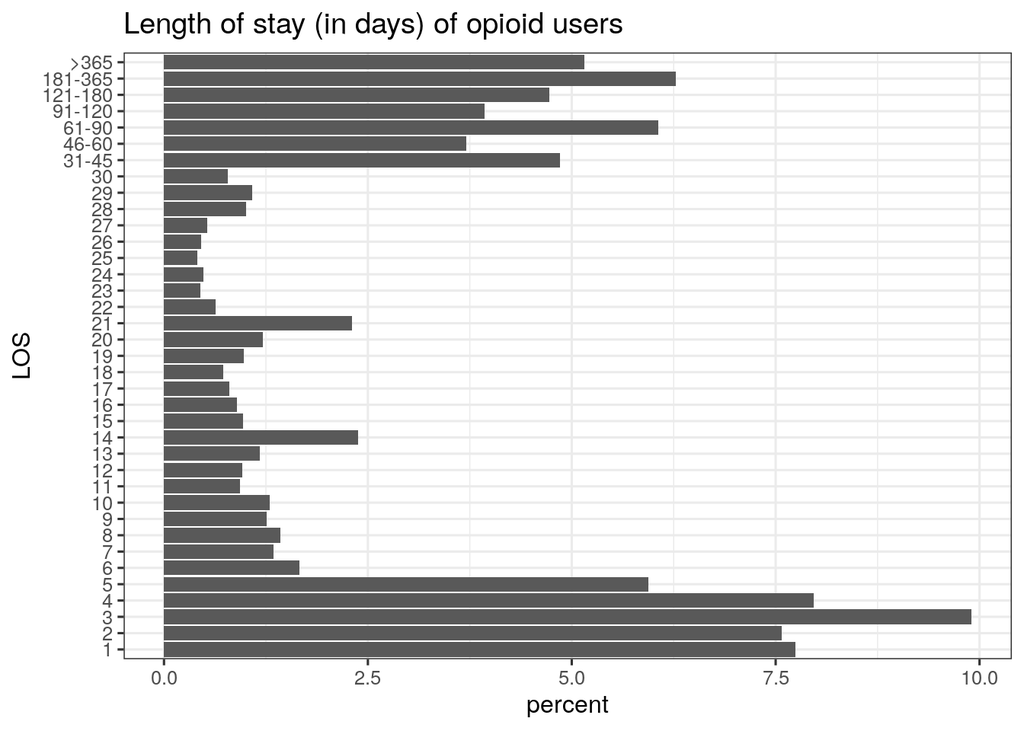

```
## LOS
##         1         2         3         4         5         6         7
## 7.7390545 7.5778942 9.9012893 7.9640075 5.9360731 1.6653237 1.3430030
##         8         9        10        11        12        13        14
## 1.4235831 1.2557078 1.2993554 0.9333871 0.9636046 1.1717701 2.3771152
##        15        16        17        18        19        20        21
## 0.9736771 0.8930970 0.7990868 0.7285791 0.9770346 1.2154177 2.3099651
##        22        23        24        25        26        27        28
## 0.6312114 0.4465485 0.4868386 0.4129734 0.4532635 0.5304862 1.0106097
##        29        30     31-45     46-60     61-90    91-120   121-180
## 1.0811174 0.7856567 4.8583132 3.7066882 6.0636583 3.9282836 4.7273704
##   181-365      >365
## 6.2751813 5.1537738
```

```r
percents_graphs_tables(~LOS, "Length of stay (in days) of opioid users", tedsd_MI2017_los,
                       horiz=TRUE)
```

```r
tally(~PSOURCE, data=tedsd_MI2017_los)
```

```
## PSOURCE
##                     Individual Alcohol/drug use care provider
##                          19002                           5206
##     Other health care provider                         School
##                           1173                              5
##                   Employer/EAP                Other community
##                             15                           1701
##                          Court
##                           2682
```

```r
los_lrm <- glmmTMB(LONGSTAY ~ AGE + EDUC + EMPLOY + FREQ_ATND_SELF_HELP + PSOURCE + OPSYNFLG + (1|rowgroups), data=tedsd_MI2017_los, family=binomial(link = "logit"))
```

```r
summary(los_lrm)
```

```
##  Family: binomial  ( logit )
## Formula:
## LONGSTAY ~ AGE + EDUC + EMPLOY + FREQ_ATND_SELF_HELP + PSOURCE +
##     OPSYNFLG + (1 | rowgroups)
## Data: tedsd_MI2017_los
##
##      AIC      BIC   logLik deviance df.resid
##  31234.7  31475.5 -15588.4  31176.7    29755
##
## Random effects:
##
## Conditional model:
##  Groups    Name        Variance Std.Dev.
##  rowgroups (Intercept) 2.08     1.442
## Number of obs: 29784, groups:  rowgroups, 254
##
## Conditional model:
##                                        Estimate Std. Error z value
## (Intercept)                             0.84205    0.47938   1.757
## AGE18-20                               -1.19719    0.47038  -2.545
## AGE21-24                               -1.08098    0.46157  -2.342
## AGE25-29                               -1.10037    0.45981  -2.393
## AGE30-34                               -1.09559    0.45989  -2.382
## AGE35-39                               -1.07457    0.46033  -2.334
## AGE40-44                               -1.04166    0.46168  -2.256
## AGE45-49                               -1.00983    0.46250  -2.183
## AGE50-54                               -0.90077    0.46292  -1.946
## AGE55-64                               -0.83667    0.46183  -1.812
## AGE65+                                 -0.84260    0.48258  -1.746
## EDUC9-11                                0.06278    0.08909   0.705
## EDUC12 or GED                           0.07599    0.08589   0.885
## EDUC13-15                               0.13161    0.08846   1.488
## EDUC16+                                 0.31703    0.11535   2.748
## EMPLOYPart-time                         0.05638    0.08213   0.686
## EMPLOYUnemployed                       -0.08468    0.06086  -1.391
## EMPLOYNot in labor force               -0.27533    0.07270  -3.787
## FREQ_ATND_SELF_HELP1-3                  0.49446    0.05673   8.716
## FREQ_ATND_SELF_HELP4-7                  0.55698    0.07013   7.942
## FREQ_ATND_SELF_HELP8-30                 0.52794    0.05613   9.406
## PSOURCEAlcohol/drug use care provider   0.81196    0.04439  18.291
```

[output cut: 22 more lines]

```
## EMPLOYPart-time                       0.492403
## EMPLOYUnemployed                      0.164134
## EMPLOYNot in labor force              0.000152 ***
## FREQ_ATND_SELF_HELP1-3                 < 2e-16 ***
## FREQ_ATND_SELF_HELP4-7                1.99e-15 ***
## FREQ_ATND_SELF_HELP8-30                < 2e-16 ***
## PSOURCEAlcohol/drug use care provider  < 2e-16 ***
## PSOURCEOther health care provider     0.103596
## PSOURCESchool                         0.986454
## PSOURCEEmployer/EAP                   0.008277 **
## PSOURCEOther community                1.66e-10 ***
## PSOURCECourt                           < 2e-16 ***
## OPSYNFLG1                             2.10e-11 ***
## ---
## Signif. codes:  0 '***' 0.001 '**' 0.01 '*' 0.05 '.' 0.1 ' ' 1
```

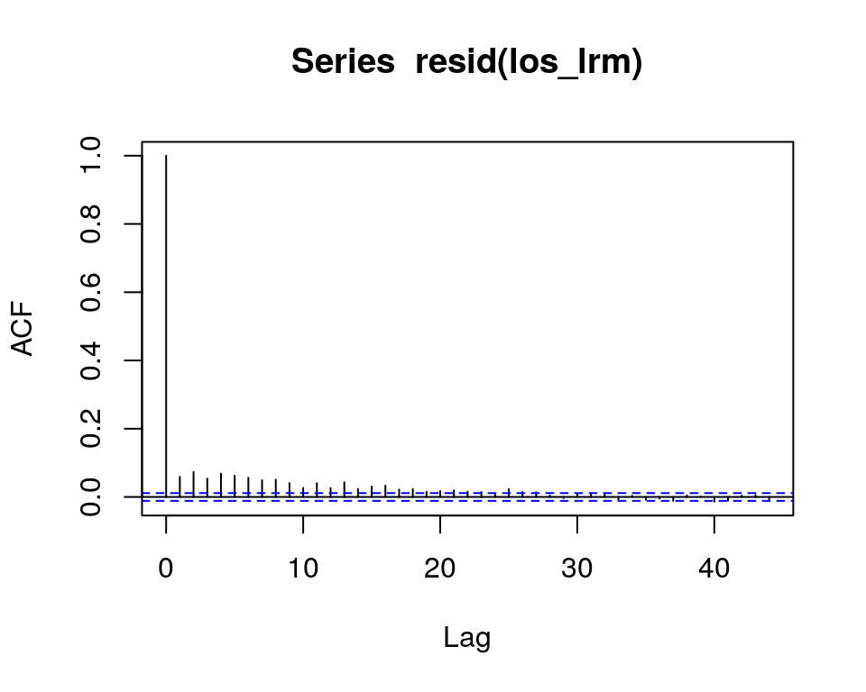

```r
acf(resid(los_lrm))
```

Again, this ACF was the best we could do. It’s a lot better than what we started with, indicating that our random effect variable (rowgroup) helped with the independence of residuals.

```r
Anova(los_lrm)
```

```
## Analysis of Deviance Table (Type II Wald chisquare tests)
##
## Response: LONGSTAY
##                       Chisq Df Pr(>Chisq)
## AGE                  33.355 10  0.0002374 ***
## EDUC                 12.270  4  0.0154515 *
## EMPLOY               26.453  3  7.666e-06 ***
## FREQ_ATND_SELF_HELP 181.980  3  < 2.2e-16 ***
## PSOURCE             483.568  6  < 2.2e-16 ***
## OPSYNFLG             44.871  1  2.104e-11 ***
## ---
## Signif. codes:  0 '***' 0.001 '**' 0.01 '*' 0.05 '.' 0.1 ' ' 1
```

##### The important predictors for predicting stays of over 2 weeks are:

Longer stay: referred by employer/EAP, referred by court, referred by alcohol/drug use care provider, attended self-help in the past month, referred by other community, 16+ years of education, other opioids & synthetics Shorter stay: 18 years or older, not in labor force

##### Prediction Plots:

We’d like to be able to show prediction plots for: freq_atnd_self_help, psource, opsynflg.